# RNA-seq analysis in R

Gene Set Testing for RNA-seq

Stephane Ballereau, Dominique-Laurent Couturier, Mark Dunning, Abbi Edwards, Ashley Sawle

Last modified: 24 Jul 2020

```r
library(tidyverse)
# load the data
load("Robjects/Annotated_Results_LvV.RData")
```

# GO enrichment analysis

## `goseq`

GOseq is a method to conduct Gene Ontology (GO) analysis suitable for RNA-seq data as it accounts for the gene length bias in detection of over-representation [(Young et al. 2010)](https://genomebiology.biomedcentral.com/articles/10.1186/gb-2010-11-2-r14).

From the [GOseq vignette](https://www.bioconductor.org/packages/release/bioc/vignettes/goseq/inst/doc/goseq.pdf):

- GOseq first needs to quantify the length bias present in the dataset under consideration.
- This is done by calculating a Probability Weighting Function or PWF which can be thought of as a function which gives the probability that a gene will be differentially expressed (DE), based on its length alone.
- The PWF is calculated by fitting a monotonic spline to the binary data series of differential expression (1=DE, 0=Not DE) as a function of gene length.
- The PWF is used to weight the chance of selecting each gene when forming a null distribution for GO category membership.
- The fact that the PWF is calculated directly from the dataset under consideration makes this approach robust, only correcting for the length bias present in the data.

```r
library(goseq)
supportedOrganisms() %>% filter(str_detect(Genome, "mm"))
```

```
## # A tibble: 10 x 5
##    Genome Id        `Id Description` `Lengths in geneLeneD… `GO Annotation Avai…
##    <chr>  <chr>     <chr>            <lgl>                  <lgl>
##  1 mm10   ""        ""               FALSE                  TRUE
##  2 mm7    "knownGe… "Entrez Gene ID" TRUE                   TRUE
##  3 mm7    "ensGene" "Ensembl gene I… TRUE                   TRUE
##  4 mm7    "geneSym… "Gene Symbol"    TRUE                   TRUE
##  5 mm8    "knownGe… "Entrez Gene ID" TRUE                   TRUE
##  6 mm8    "ensGene" "Ensembl gene I… TRUE                   TRUE
##  7 mm8    "geneSym… "Gene Symbol"    TRUE                   TRUE
##  8 mm9    "knownGe… "Entrez Gene ID" TRUE                   TRUE
##  9 mm9    "ensGene" "Ensembl gene I… TRUE                   TRUE
## 10 mm9    "geneSym… "Gene Symbol"    TRUE                   TRUE
```

## Create a list of differentially expressed genes

The input for `goseq` is a vector that indicates, for each gene, whether or not it is significantly differentially expressed. This should be a named vector, where the names are the gene ids and the values are *`1`* if the gene is significant and *`0`* if it is not.

In this case we can use the Ensembl gene IDs.

```r
sigData <- as.integer(!is.na(shrinkLvV$FDR) & shrinkLvV$FDR < 0.01)
names(sigData) <- shrinkLvV$GeneID
```

## Fit the Probability Weighting Function (PWF)

```r
pwf <- nullp(sigData, "mm10", "ensGene", bias.data = shrinkLvV$medianTxLength)
```

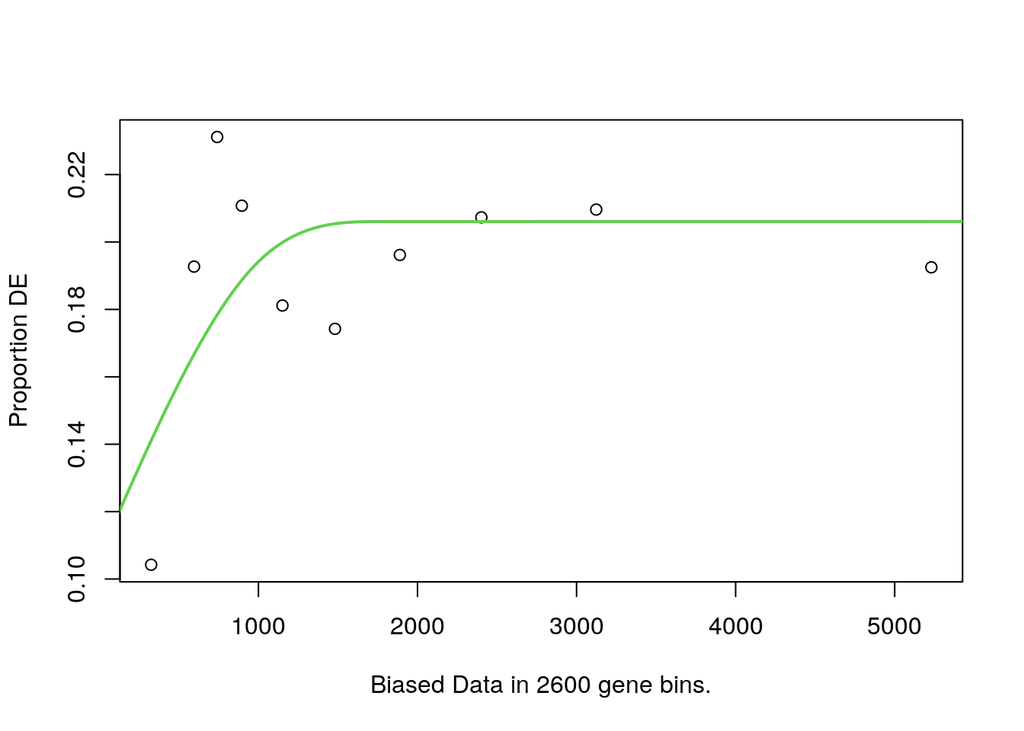

## Conduct GO enrichment analysis

```r
goResults <- goseq(pwf, "mm10","ensGene", test.cats=c("GO:BP"))
```

## Plot the top 10

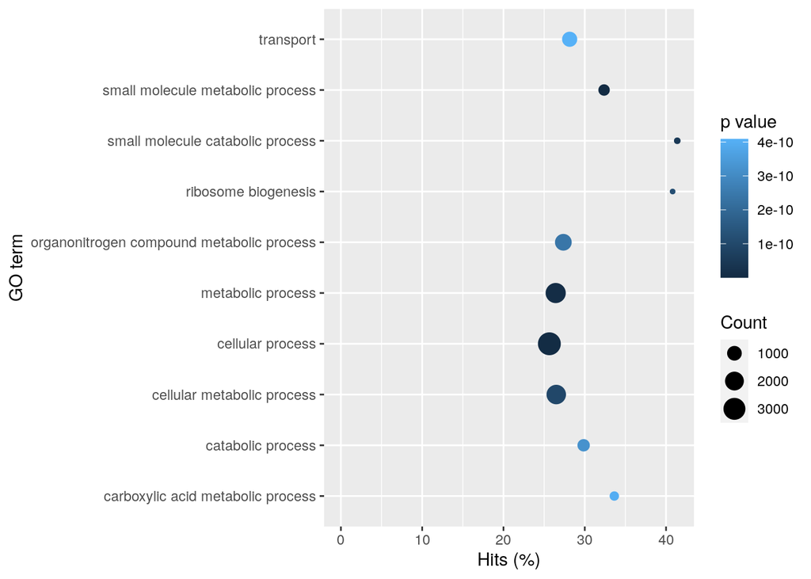

```r
goResults %>%
    top_n(10, wt=-over_represented_pvalue) %>%
    mutate(hitsPerc=numDEInCat*100/numInCat) %>%
    ggplot(aes(x=hitsPerc,
               y=term,
               colour=over_represented_pvalue,
               size=numDEInCat)) +
        geom_point() +
        expand_limits(x=0) +
        labs(x="Hits (%)", y="GO term", colour="p value", size="Count")
```

## Get the GO information for the GO accessions

```r
library(GO.db)
GOTERM[[goResults$category[1]]]
```

```
## GOID: GO:0044281
## Term: small molecule metabolic process
## Ontology: BP
## Definition: The chemical reactions and pathways involving small
##     molecules, any low molecular weight, monomeric, non-encoded
##     molecule.
## Synonym: small molecule metabolism
```

## Challenge 2

> 1. Create a vector showing genes that are statistically significant at FDR < 0.01 and that are up-regulated by at least 4x (logFC>2) in lactating mice
> 2. Run a `goseq` analysis on this gene list
> 3. Plot the results
> 4. How is this result different to the previous GO analysis?

Young, Matthew D, Matthew J Wakefield, Gordon K Smyth, and Alicia Oshlack. 2010. “Gene Ontology Analysis for Rna-Seq: Accounting for Selection Bias.” *Genome Biology* 11: R14.